# main

bationoA

2023-04-08

# Case Study: How does a bike-share navigate speedy success?

In this case study we will work for a fictional company, Cyclistic, a bike-share company in Chicago. For the director of marketing of the company’s, future success depends on maximizing the number of annual memberships. Therefore, rather than creating a marketing campaign that targets all-new customers, the director of marketing believes there is a very good chance to convert casual riders into members.

Source: Link

In order to help the company design a new marketing strategy to convert casual riders into annual members, some questions need to be answered

- 1. How do annual members and casual riders use Cyclistic bikes differently?
- 2. Why would casual riders buy Cyclistic annual memberships?
- 3. How can Cyclistic use digital media to influence casual riders to become members?

This case study will focus on the first question.

## 1. Business task

The objective is to analyze and compare the usage habits of annual members and casual riders of Cyclistic bicycles in order to identify differences in their behavior and preferences. The goal is to gain insights that can be used to design effective marketing strategies to convert casual cyclists into annual members. By understanding the key factors that influence user behavior and preferences, Cyclistic can tailor its marketing efforts to better meet the needs of casual cyclists and encourage them to become long-term loyal customers.

## 2. Description of data sources

The data used in this study are Cyclistic’s historical trip data. The initial case study suggests to get only the previous 12 months trips data but we will consider all data (from January 2015 to March 2023). This could give more insights regarding changes over years.

There are several csv files containing trips data ([seen list sata sets here](https://divvy-tripdata.s3.amazonaws.com/index.html)). The name of variables are not consistent across all data sets but they contain similar information. The information that can be found in these data sets are:

- trip_id: ID attached to each trip taken
- start_time: day and time trip started, in CST
- stop_time: day and time trip ended, in CST
- bikeid: ID attached to each bike
- tripduration: time of trip in seconds
- from_station_name: name of station where trip originated
- to_station_name: name of station where trip terminated
- from_station_id: ID of station where trip originated
- to_station_id: ID of station where trip terminated
- usertype: “Customer” is a rider who purchased a 24-Hour Pass; “Subscriber” is a rider who purchased an Annual Membership
- gender: gender of rider

## 3. Summary of analysis

**Key Findings**

### 1. In general

The longest ride length for casual bikers was 238,940 minutes, which is more than 165 days! The longest ride length for members was 225,960 minutes, which is also a very long time. The minimum riding time for both groups was 5 minutes, indicating that some rides may have been cut short for various reasons. Overall, these statistics indicate that our dataset has a wide variety of ride lengths, with some being quite short and others being exceedingly long. These information might help uncover trends and patterns in ride length, which could help drive decision-making in areas like route design and pricing strategies.

Comment: After removing the outliers it appears that ‘member’ subscription type of customers tend to use the bikes for shorter trips compared to the ‘casual’ customers. Let’s assess the strength of this hypothesis through a statistical test.

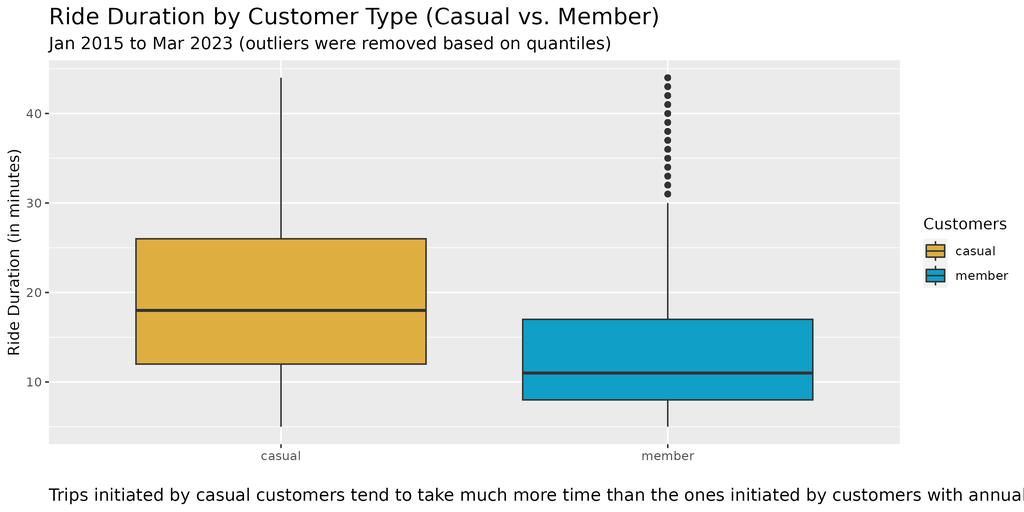

### 2. Annual

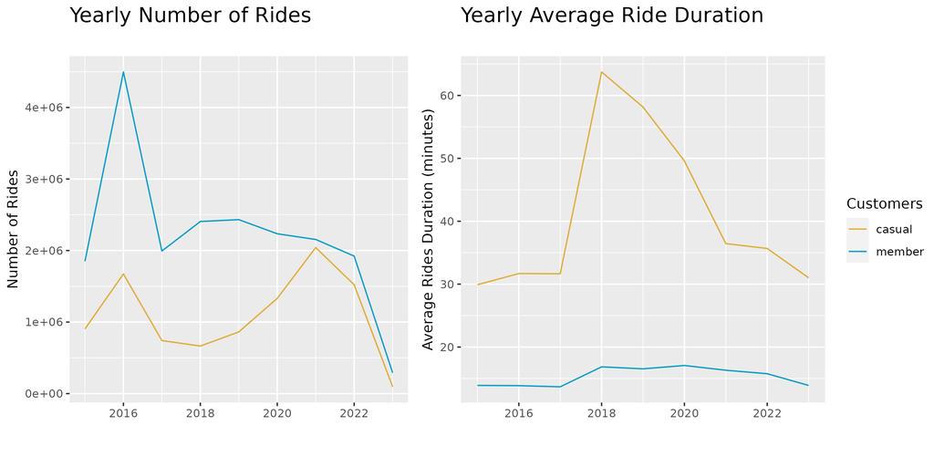

### 3. Monthly

Comment: The number of bike rides for each type of customer appears to be normally distributed over the months. However, there is a clear trend that annual subscribers (‘member’) have been taking more bike trips per month compared to casual customers since 2015.

Comment: Based on the data, it appears that there is a significant difference in the average trip duration between casual customers and annual subscribers (‘member’) on a monthly basis. Despite a slight decrease in the average duration over time, casual customers consistently take longer bike trips compared to annual subscribers.

Comment: The average time spent for monthly trips by casual customers is more than the double of the average time spent by member customers.

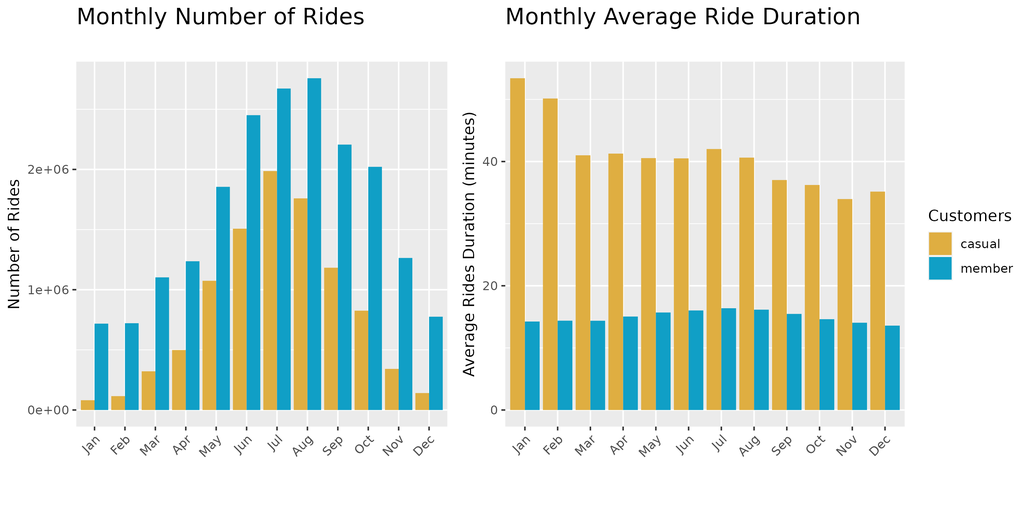

### 4. Daily

Comment: From 2015 to March 2023, casual customers have been using the bikes for longer than member customers

Comment: The average time spent for daily trips by casual customers is more than the double of the average time spent by member customers.

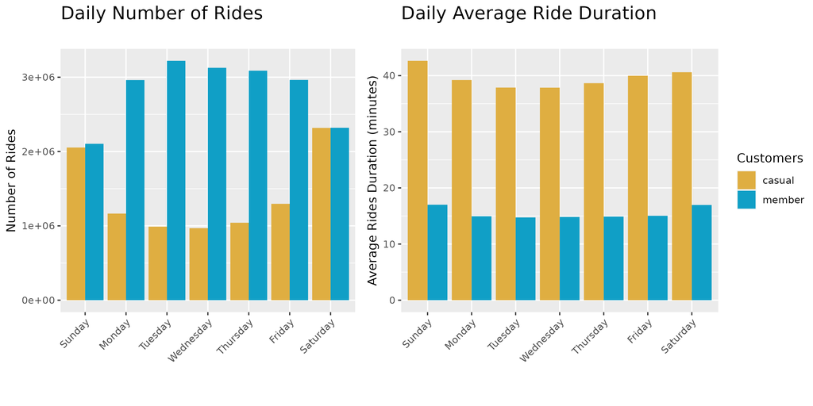

### 5. Testing the difference of trips duration between casual and member customers

From the above analysis it appeared that a clear difference exists between casual and member customers when it comes to the duration of their rides. In this section we’ll use statistical tests to evaluate the significance of this difference. The tests will be on central trends such as means or medians.

The question we’re trying to answer here is: Is there a significant difference in the duration of the trips between the two categories of customers (casual and member)? The results of different tests conducted are summarized in the bellow table.

Test Results

| Test | H0 | Alpha | P_value | Reject_H0 |
| --- | --- | --- | --- | --- |
| Levene - Homogeneity of variance | variance in casual group is equal (statistically) to variance in member group | 0.05 | p-value < 1e-05 | Yes (99.99%) |
| Shapiro - normality of distribution - casual customers | The data are normally distributed | 0.05 | p-value < 1e-05 | Yes (99.99%) |
| Shapiro - normality of distribution - member customers | The data are normally distributed | 0.05 | p-value < 1e-05 | Yes (99.99%) |
| T-Test - Equality of means | averages trips duration for casual and member customers are not statistically different | 0.05 | p-value < 1e-05 | Yes (99.99%) |
| Wilcoxon rank-sum test - Equality of medians | median value of trips duration for ‘casual’ and ‘member’ customers are not statistically different | 0.05 | p-value < 1e-05 | Yes (99.99%) |

We’ve decided to run a T-Test (Student test) to compare the average trip duration of casual and member customers.

First, we ran a homogeneity of variance test to check if the variances of the data were not statistically different in both groups. The result was not in our favor, and we had to reject the null hypothesis with more than 99.99% confidence. Next, we ran a normality test, which showed that the duration of the rides for both categories was not normally distributed. The results of these these two violate the assumptions of a T-Test. These violations of assumptions were taken into account before proceeding with the T-Test.

Despite the violated assumptions, we decided to conduct a T-Test, which resulted in rejecting the null hypothesis with more than 99.99% confidence. This means that there is a statistically significant difference in the average duration of trips between the two categories of customers. However, it was crucial to note that the assumptions for the T-Test were violated, therefore alternative tests are needed to add credit to this conclusion.

Finally, we decided to go for a non-parametric test (no assumptions are required) called the Wilcoxon rank-sum, which tests the equality of medians. The result was in our favor as we had to reject the null hypothesis with more than 99.99% confidence. Thus, we concluded that the difference in the duration of trips between casual and member customers was statistically significant, regardless of the type of test used.

### 6. Top 5 starting stations by customers type (members vs casual users)

There is a clear difference between casual and member customers in terms of starting station. Most casual riders start their trips at the Streeter Dr & Grand Ave’ station (457,718 trips), with more than 2 times the number of started rides by member customers (124,443 trips). In the other hand member customers mostly go to the Clinton St & Washington Blvd’ station to pick up a bike for their trip. However their number of rides (278,769 trips) less differ from the one of casual customers as it is just 0.92 times higher than the number of rides of casual customers.

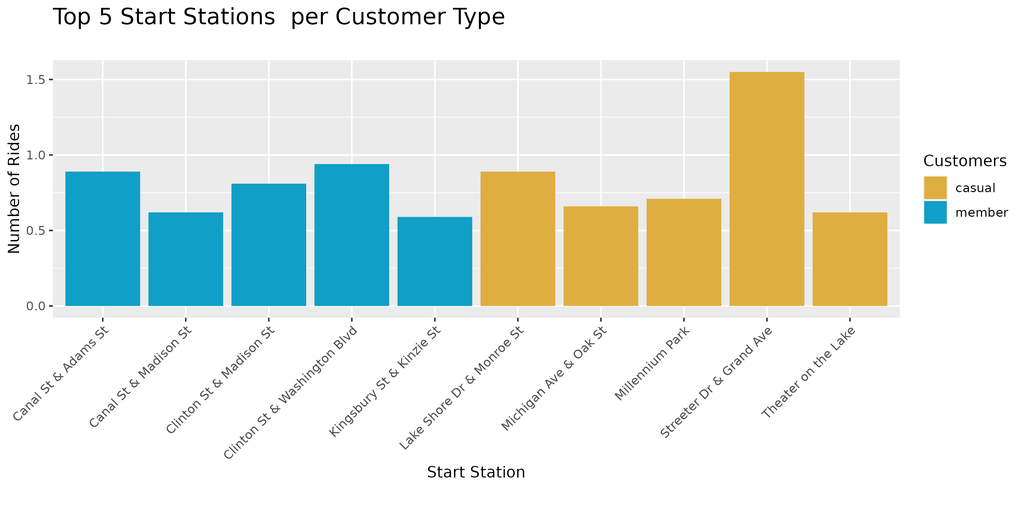

### 7. Bikes preference by customers type

Comment: The most frequently used bikes among all customers are classic bikes, accounting for approximately 44.59% of all trips. Since 2020, customers with annual subscriptions have been using classic bikes more frequently, making up 60.78% of all trips. The use of docked bikes is quite similar for both customer types, with casual riders accounting for 50.46% of trips made with these bikes.

One finding is that there is a difference in the preferred bike type between casual riders and customers with annual subscription. Casual riders tend to use docked bikes more frequently than electric bikes, while customers with annual subscription tend to use electric bikes more frequently than docked bikes even if both tend to use classic bikes much more often than the others type of bikes.

More analysis is needed in order to determine if is really a matter of preference of availability.

In terms of trip duration, no matter which type of bike is considered, casual customers tend to use them much longer during each ride than customers with annual subscriptions. Indeed, casual riders use docked bikes at least two times longer than member customers (67 versus 18 minutes) , while classic and electric bikes have average trip duration of 31 and 20 minutes, respectively.

Electric bikes are used for shorter trips by both casual and member customers, which could be attributed to the battery life, even though most electric bikes can still be used as classic bikes with low battery power. Further analysis could be done to investigate the reason behind this difference in duration among bike types.

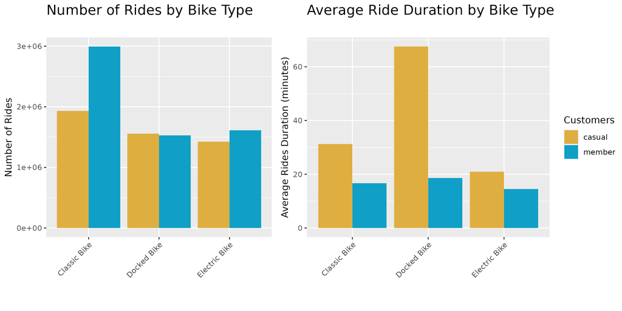

## 4. Recommendations for an effective marketing strategy

- **1. Offer promotions and discounts for annual memberships during weekdays**: Member customers tend to use the bikes more often. This can encourage casual riders to become members and take advantage of the benefits of more frequent rides during weekdays.
- **2. Promote the benefits of annual membership for weekend riders**: Although casual and member customers have similar number of rides during weekends, annual members have more flexibility to take longer trips without worrying about extra fees. Marketing campaigns should emphasize this benefit to encourage casual riders to become annual members.
- **3. Offer incentives to encourage casual riders to use docked bikes more often**: Since casual riders account for the majority of trips made with docked bikes, incentives such as discounts or free rides can encourage them to become more loyal customers and potentially convert to annual members.
- **4. Focus marketing efforts on promoting the benefits of using bikes from different starting stations**: Since casual customers tend to use a specific starting station much more often, marketing campaigns should focus on the benefits of exploring different areas and using bikes from different starting stations. This can encourage casual riders to become more adventurous and potentially become annual members.
- **5. Highlight the cost savings of annual memberships for frequent riders**: The analysis shows that casual riders tend to use bikes for longer duration than annual members. Promoting the cost savings of an annual membership for frequent riders can encourage casual riders to become members and take advantage of the cost savings for longer trips.
- **6. Offer membership trial periods**: The company can offer casual riders the chance to try out the annual membership for a certain period of time (e.g. a week or a month) to see if they would benefit from the service. This can help to increase the number of annual members by giving casual riders a chance to experience the benefits of an annual membership without committing to it fully.
- **7. Create a community for annual members**: Since annual members tend to be more frequent users of the service, the company can create a community for them to promote social interaction and encourage them to use the service more often. This can help to increase their loyalty to the service and encourage casual riders to convert to annual members.

## 5. For further analysis

Further data collection analysis can be conducted in order to have a better understanding of the customers and increase annual subscription while providing a better service to customers:

- Conduct a quick survey to understand more the reason to of choosing (or not) annual subscription and what they use the bikes for.
- Conduct a neighborhood analysis around different stations as well as between start and end stations?